# Introduction to olsrr

## Introduction

The olsrr package provides following tools for teaching and learning OLS regression using R:

- comprehensive regression output
- residual diagnostics
- measures of influence
- heteroskedasticity tests
- collinearity diagnostics
- model fit assessment
- variable contribution assessment
- variable selection procedures

This document is a quickstart guide to the tools offered by **olsrr**. Other vignettes provide more details on specific topics:

- Residual Diagnostics: Includes plots to examine residuals to validate OLS assumptions
- Variable selection: Differnt variable selection procedures such as all possible regression, best subset regression, stepwise regression, stepwise forward regression and stepwise backward regression
- Heteroskedasticity: Tests for heteroskedasticity include bartlett test, breusch pagan test, score test and f test
- Measures of influence: Includes 10 different plots to detect and identify influential observations
- Collinearity diagnostics: VIF, Tolerance and condition indices to detect collinearity and plots for assessing mode fit and contributions of variables

## Regression

```r
ols_regress(mpg ~ disp + hp + wt + qsec, data = mtcars)
```

```
##                         Model Summary
## --------------------------------------------------------------
## R                       0.914       RMSE                2.622
## R-Squared               0.835       Coef. Var          13.051
## Adj. R-Squared          0.811       MSE                 6.875
## Pred R-Squared          0.771       MAE                 1.858
## --------------------------------------------------------------
##  RMSE: Root Mean Square Error
##  MSE: Mean Square Error
##  MAE: Mean Absolute Error
##
##                                ANOVA
## --------------------------------------------------------------------
##                 Sum of
##                Squares        DF    Mean Square      F         Sig.
## --------------------------------------------------------------------
## Regression     940.412         4        235.103    34.195    0.0000
## Residual       185.635        27          6.875
## Total         1126.047        31
## --------------------------------------------------------------------
##
##                                   Parameter Estimates
## ----------------------------------------------------------------------------------------
##       model      Beta    Std. Error    Std. Beta      t        Sig      lower     upper
## ----------------------------------------------------------------------------------------
## (Intercept)    27.330         8.639                  3.164    0.004     9.604    45.055
##        disp     0.003         0.011        0.055     0.248    0.806    -0.019     0.025
##          hp    -0.019         0.016       -0.212    -1.196    0.242    -0.051     0.013
##          wt    -4.609         1.266       -0.748    -3.641    0.001    -7.206    -2.012
##        qsec     0.544         0.466        0.161     1.166    0.254    -0.413     1.501
## ----------------------------------------------------------------------------------------
```

In the presence of interaction terms in the model, the predictors are scaled and centered before computing the standardized betas. `ols_regress()` will detect interaction terms automatically but in case you have created a new variable instead of using the inline function `*`, you can indicate the presence of interaction terms by setting `iterm` to `TRUE`.

## Residual vs Fitted Values Plot

Plot to detect non-linearity, unequal error variances, and outliers.

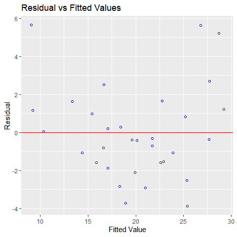

```r
model <- lm(mpg ~ disp + hp + wt + qsec, data = mtcars)
ols_plot_resid_fit(model)
```

## DFBETAs Panel

DFBETAs measure the difference in each parameter estimate with and without the influential observation. `dfbetas_panel` creates plots to detect influential observations using DFBETAs.

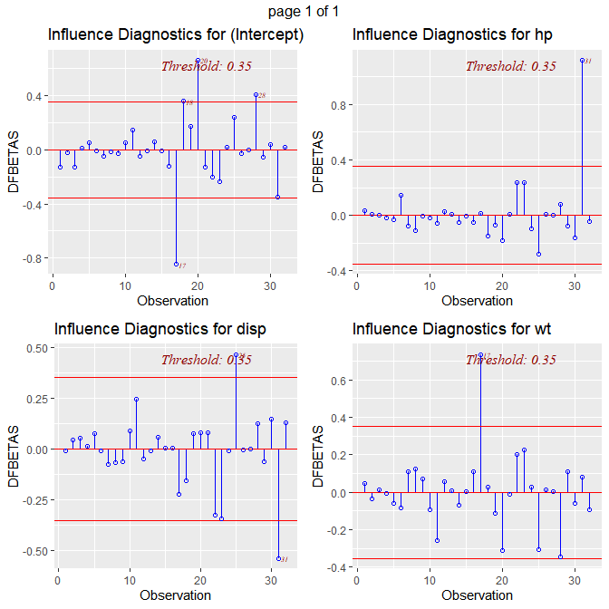

```r
model <- lm(mpg ~ disp + hp + wt, data = mtcars)
ols_plot_dfbetas(model)
```

## Residual Fit Spread Plot

Plot to detect non-linearity, influential observations and outliers.

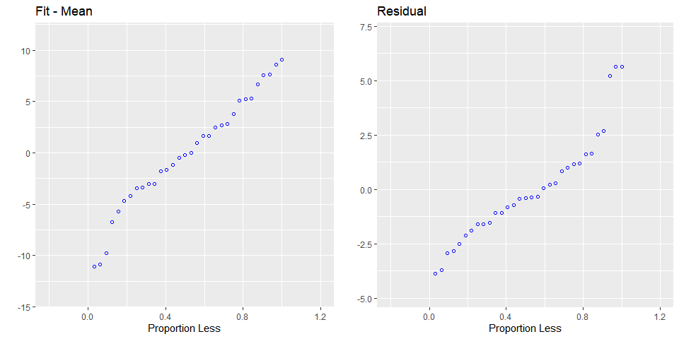

```r
model <- lm(mpg ~ disp + hp + wt + qsec, data = mtcars)
ols_plot_resid_fit_spread(model)
```

## Breusch Pagan Test

Breusch Pagan test is used to test for herteroskedasticity (non-constant error variance). It tests whether the variance of the errors from a regression is dependent on the values of the independent variables. It is a $\chi^{2}$ test.

```r
model <- lm(mpg ~ disp + hp + wt + drat, data = mtcars)
ols_test_breusch_pagan(model)
```

```
##
##  Breusch Pagan Test for Heteroskedasticity
##  -----------------------------------------
##  Ho: the variance is constant
##  Ha: the variance is not constant
##
##              Data
##  -------------------------------
##  Response : mpg
##  Variables: fitted values of mpg
##
##        Test Summary
##  ---------------------------
##  DF            =    1
##  Chi2          =    1.429672
##  Prob > Chi2   =    0.231818
```

## Collinearity Diagnostics

```r
model <- lm(mpg ~ disp + hp + wt + qsec, data = mtcars)
ols_coll_diag(model)
```

```
## Tolerance and Variance Inflation Factor
## ---------------------------------------
##   Variables Tolerance      VIF
## 1      disp 0.1252279 7.985439
## 2        hp 0.1935450 5.166758
## 3        wt 0.1445726 6.916942
## 4      qsec 0.3191708 3.133119
##
##
## Eigenvalue and Condition Index
## ------------------------------
##    Eigenvalue Condition Index   intercept        disp          hp
## 1 4.721487187        1.000000 0.000123237 0.001132468 0.001413094
## 2 0.216562203        4.669260 0.002617424 0.036811051 0.027751289
## 3 0.050416837        9.677242 0.001656551 0.120881424 0.392366164
## 4 0.010104757       21.616057 0.025805998 0.777260487 0.059594623
## 5 0.001429017       57.480524 0.969796790 0.063914571 0.518874831
##             wt         qsec
## 1 0.0005253393 0.0001277169
## 2 0.0002096014 0.0046789491
## 3 0.0377028008 0.0001952599
## 4 0.7017528428 0.0024577686
## 5 0.2598094157 0.9925403056
```

## Stepwise Regression

Build regression model from a set of candidate predictor variables by entering and removing predictors based on p values, in a stepwise manner until there is no variable left to enter or remove any more.

### Variable Selection

```r
# stepwise regression
model <- lm(y ~ ., data = surgical)
ols_step_both_p(model)
```

```
##
##                                 Stepwise Selection Summary
## ------------------------------------------------------------------------------------------
##                         Added/                   Adj.
## Step     Variable      Removed     R-Square    R-Square     C(p)        AIC         RMSE
## ------------------------------------------------------------------------------------------
##    1    liver_test     addition       0.455       0.444    62.5120    771.8753    296.2992
##    2     alc_heavy     addition       0.567       0.550    41.3680    761.4394    266.6484
##    3    enzyme_test    addition       0.659       0.639    24.3380    750.5089    238.9145
##    4      pindex       addition       0.750       0.730     7.5370    735.7146    206.5835
##    5        bcs        addition       0.781       0.758     3.1920    730.6204    195.4544
## ------------------------------------------------------------------------------------------
```

### Plot

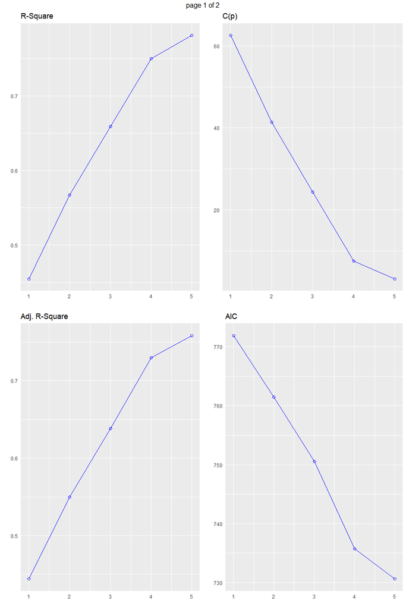

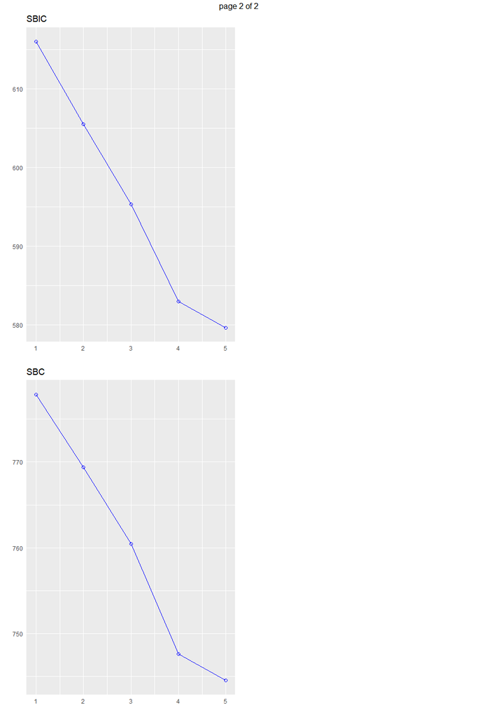

```r
model <- lm(y ~ ., data = surgical)
k <- ols_step_both_p(model)
plot(k)
```

## Stepwise AIC Backward Regression

Build regression model from a set of candidate predictor variables by removing predictors based on Akaike Information Criteria, in a stepwise manner until there is no variable left to remove any more.

### Variable Selection

```r
# stepwise aic backward regression
model <- lm(y ~ ., data = surgical)
k <- ols_step_backward_aic(model)
k
```

```
##
##
##                         Backward Elimination Summary
## ---------------------------------------------------------------------------
## Variable        AIC          RSS          Sum Sq        R-Sq      Adj. R-Sq
## ---------------------------------------------------------------------------
## Full Model    736.390    1825905.713    6543614.824    0.78184      0.74305
## alc_mod       734.407    1826477.828    6543042.709    0.78177      0.74856
## gender        732.494    1829435.617    6540084.920    0.78142      0.75351
## age           730.620    1833716.447    6535804.090    0.78091      0.75808
## ---------------------------------------------------------------------------
```

### Plot

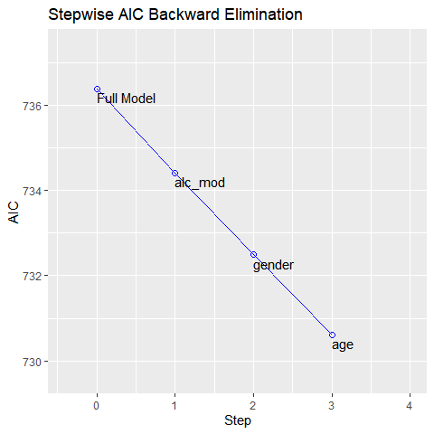

```r
model <- lm(y ~ ., data = surgical)
k <- ols_step_backward_aic(model)
plot(k)
```